# Homework 1: Perceptrons

This assignment is due on Gradescope by **11:59pm on Thursday, April 10th**. Your solutions to theoretical questions should be done in Markdown with LaTeX directly below the associated question. Your solutions to computational questions should include any specified Python code and results as well as written commentary on your conclusions. Remember that, while you're welcome to discuss the homework with your classmates at a high level **you must write all your code and your solutions on your own**. Before moving on, please refresh yourself by reading our **Academic Honesty Policy** [here](https://canvas.uchicago.edu/courses/63749/assignments/syllabus).

**NOTES**:

- Do **NOT** load or use any Python packages that are not available in Anaconda with Python 3.12.
- Some problems with code may be autograded. If we provide a function API **do not** change it. If we do not provide a function API then you're free to structure your code however you like.
- Also for the autograder to work, please **do not** add or remove cells in the notebook
- Submit this Jupyter notebook **both** as a .ipynb file and a pdf to Canvas. Do not compress either using tar, rar, zip, etc.

**Please put your name below.**

**Name**:

```python
import math
import pickle
import gzip
import numpy as np
import pandas
import matplotlib.pylab as plt
%matplotlib inline
```

## [100 points] Perceptron Training

Consider a binary classification problem on the following dataset:

| x1 | x2 | x3 | y |
| --- | --- | --- | --- |
| 0 | 0 | 0 | -1 |
| 0 | 0 | 1 | 1 |
| 0 | 1 | 0 | 1 |
| 1 | 0 | 0 | 1 |
| 0 | 1 | 1 | -1 |
| 1 | 1 | 0 | -1 |
| 1 | 0 | 1 | -1 |
| 1 | 1 | 1 | 1 |

You are going to experiment with the Perceptron algorithm in this problem.

### Part 1 [10 points]

Complete the `perceptron_train` function and report the results. Note: for this part you should **not** randomly shuffle the order of the data.

```python
# Do not change - unless needed
data = np.array([
    [0, 0, 0, 1, 0, 1, 1, 1],
    [0, 0, 1, 0, 1, 1, 0, 1],
    [0, 1, 0, 0, 1, 0, 1, 1],
    [-1, 1, 1, 1, -1, -1, -1, 1]
])
data = np.transpose(data)
# Initialize the weights and bias
weights = np.array([0, 0.5, 0.5])
bias = 1
```

Notice that we are using a non-standard initialization here.

```python
def perceptron_train(data, weights, bias):
    """
    Train a Perceptron algorithm and update weights and bias
    :param data (array): data to train model on
    :param weights (array): initial weights
    :param bias (int): initial bias

    :type X: array
    :type y: int
    :rtype: weights (array), bias (int), number of mistakes (int)
    """
    mistakes_count = 0
    for row in data:
        X = np.array(row[:3])
        y = row[-1]

        activation = np.dot(weights, X) + bias
        y_pred = 1 if activation >= 0 else -1

        if y_pred != y:
            weights = weights + y * X
            bias = bias + y
            mistakes_count += 1

    return weights, bias, mistakes_count
```

#### Part 1 A [5 points]

Report the weights, bias, and number of mistakes after the first epoch.

```python
### Do not change or remove this code
weights, bias, number_of_mistakes = perceptron_train(data, weights, bias)
print(f'weights: {weights}, bias: {bias}, mistakes: {number_of_mistakes}')
```

```
weights: [1.  0.5 0.5], bias: 0, mistakes: 3
```

```python
# for grading - ignore
```

#### Part 1 B [5 points]:

Run the Perceptron training for 50 more epochs with the updated weights and report the weights, bias and number of mistakes.

```python
epochs = 50
for i in range(epochs):
    weights, bias, number_of_mistakes = perceptron_train(data, weights, bias)

print(f'weights: {weights}, bias: {bias}, mistakes: {number_of_mistakes}')
```

```
weights: [1.  0.5 0.5], bias: -1, mistakes: 4
```

```python
# for grading - ignore
```

### Part 2 [10 points]

Imagine that your Perceptron classifier is not perfect after the first epoch. Is it possible that your Perceptron classifier would ever perfectly classify all training examples after more epochs of the Perceptron Algorithm?

Clearly explain your reasoning. Recall from CAPP 271 that you can use an example to show that something is possible.

The perceptron algorithm has the property that if the training data is linearly separable, it is guaranteed to converge to a solution that perfectly classifies all the data—even if the first epoch (or initial iterations) does not achieve perfect classification. This is known as the **Perceptron Convergence Theorem**.

#### Theoretical Explanation

1. **Perceptron Update Rule:**
   For each training example $(X, y)$, the perceptron computes the activation as: $$ \text{activation} = \text{dot}(weights, X) + bias $$ and then predicts $y_{\text{pred}} = 1$ if $\text{activation} \geq 0$ (and $-1$ otherwise). If $y_{\text{pred}}$ does not match the actual label (y), the weights and bias are updated: $$ weights \leftarrow weights + y \times X $$ $$ bias \leftarrow bias + y $$
2. **Convergence Guarantee:**  
   The Perceptron Convergence Theorem tells us that if the training data is **linearly separable** (i.e., there exists a hyperplane that can separate the two classes), then there exists a finite number of updates (or epochs) after which the perceptron will perfectly classify all examples.  
   This means that even if the classifier makes mistakes in the initial epochs, continued updates (running more epochs) will eventually lead to a set of weights and bias that yield zero errors on the training set.

#### Concrete Example

Imagine we have a simple two-dimensional dataset as follows:

- **Positive Class (+1):**
  - $(2, 3)$
  - $(3, 3)$
- **Negative Class (-1):**
  - $(0, 1)$
  - $(1, 0)$

##### Step-by-Step Demonstration

1. **Initial Setup:**  
   Assume we start with initial weights $ \mathbf{w} = [0, 0] $ and bias $ b = 0 $. With these initial parameters, the classifier is essentially making random predictions (or might favor the positive class, depending on how the rule is implemented when activation is exactly zero).
2. **First Epoch:**  
   During the first pass (epoch) through the data:
   - Some data points may be misclassified. For example, when predicting $(2, 3)$, the activation might be 0 (or a small number) leading to a specific prediction, but another point, say $(0, 1)$ with label $-1$, might be misclassified as $+1$.
   - Each misclassification will trigger an update of the weights and bias.
3. **Subsequent Epochs:**
   In the following epochs, the algorithm continues to adjust the weights and bias based on misclassifications. For instance, if ((0,1)) was incorrectly classified, the update rule would adjust the parameters in a way that shifts the decision boundary to better account for that example: $$ \mathbf{w}_{new} = \mathbf{w}_{old} + (-1) \times [0, 1] $$ $$ b_{new} = b_{old} - 1 $$ Over multiple epochs, these adjustments cumulatively improve the ability of the classifier to distinguish between the positive and negative examples.
4. **Convergence Example:**  
   Suppose after several epochs, the perceptron converges to weights $ \mathbf{w} = [1, 1] $ and bias $ b = -4 $. We can check the classification:
   - For $(2, 3)$ with label $+1$: $$ \text{activation} = 1 \times 2 + 1 \times 3 - 4 = 2 + 3 - 4 = 1 \quad (\geq 0, \text{ correct}) $$
   - For $(3, 3)$ with label $+1$: $$ \text{activation} = 1 \times 3 + 1 \times 3 - 4 = 3 + 3 - 4 = 2 \quad (\geq 0, \text{ correct}) $$
   - For $(0, 1)$ with label $-1$: $$ \text{activation} = 1 \times 0 + 1 \times 1 - 4 = 0 + 1 - 4 = -3 \quad (< 0, \text{ correct}) $$
   - For $(1, 0)$ with label $-1$: $$ \text{activation} = 1 \times 1 + 1 \times 0 - 4 = 1 + 0 - 4 = -3 \quad (< 0, \text{ correct}) $$

   At this point, every training example is correctly classified. This demonstrates that, while the perceptron might start off imperfectly after the first epoch, if the data is linearly separable, running more epochs will eventually lead to perfect classification.

#### Conclusion

Yes, it is possible perceptron classifier to eventually perfectly classify all training examples after multiple epochs—even if it is not perfect after the first epoch—provided that the training data is linearly separable. This phenomenon is explained by the Perceptron Convergence Theorem and demonstrated by the example above.

### Part 3 [10 points]

Does the Perceptron classifier always make the same number of mistakes after the first epoch if the data is presented in a different randomized order?

Clearly explain your reasoning. Again, recall from CAPP 271 that you can use a counterexample to show that something isn't always true.

The answer is **no**—the perceptron classifier does not always make the same number of mistakes after the first epoch if we change the order in which the data is presented. Here’s why:

#### Explanation

1. **Order-Dependent Updates:**  
   The perceptron algorithm updates its weights and bias immediately whenever it encounters a misclassified example. This means that the sequence of examples can affect the state of the model for subsequent examples in that same epoch. A different ordering can lead to different adjustments early on, which in turn may alter the predictions on later examples.
2. **Accumulated Effects:**  
   Consider that an update made on one misclassified example may help correctly classify some later examples, or conversely, if an update is done in a different order, it might worsen the prediction for subsequent examples. This cumulative effect can lead to a varying number of mistakes being made during the epoch.
3. **Counterexample:**  
   Imagine a simple scenario with two training points:
   - Example A: $X_A = [1], y_A = 1$
   - Example B: $X_B = [2], y_B = -1$

   Suppose we initialize the weight to $ w = 0 $ and bias $ b = 0 $.

   **Order 1:** A then B
   - **First, Example A:**  
     $ \text{activation} = 0 \times 1 + 0 = 0 $  
     Prediction: $1$ (since we treat 0 as $ \geq 0 $ → 1)  
     This is correct because $y_A = 1$ so no update.
   - **Next, Example B:**
     $\text{activation} = 0 \times 2 + 0 = 0 $
     Prediction: $1$ but $y_B = -1$
     This is an error, so the update:
     $$ w \leftarrow 0 + (-1) \times 2 = -2, \quad b \leftarrow 0 + (-1) = -1 $$
     Total mistakes: 1

   **Order 2:** B then A
   - **First, Example B:**
     $ \text{activation} = 0 \times 2 + 0 = 0 $
     Prediction: $1$ but $y_B = -1$
     This is an error, so the update:
     $$ w \leftarrow 0 + (-1) \times 2 = -2, \quad b \leftarrow 0 + (-1) = -1 $$
   - **Next, Example A:**
     Now for Example A, we have:
     $ \text{activation} = (-2) \times 1 + (-1) = -3 $
     Prediction: $-1$ but $y_A = 1$
     This is an error, so update:
     $$ w \leftarrow -2 + 1 \times 1 = -1, \quad b \leftarrow -1 + 1 = 0 $$ Total mistakes: 2

   In this counterexample, presenting the data in one order resulted in 1 mistake during the epoch, whereas the reversed order resulted in 2 mistakes.

#### Conclusion

Because the perceptron algorithm updates its parameters sequentially and these updates affect predictions for subsequent examples, the number of mistakes in the first epoch can vary depending on the order in which the training data is presented. This order-dependence is why the algorithm might make a different number of mistakes even though the overall data is the same.

### Part 4 [45 Points]: Perceptron Classifier on random generated data

Update the Perceptron Learning Algorithm to explore the convergence on linearly separable simulated data sets with particular properties. Carefully read the `Perceptron` class below.

```python
class Perceptron:
    """
    Class to fit a Perceptron classifier to simulated data
    """

    def __init__(self, n=100, margin=0.1, X=None, y=None, random_state=1241):
        """
        Initializes Perceptron class.  Generates training data and sets parameters.

        :param n (int): the number of training examples
        :param margin (float): the margin between decision boundary and data
        :param random_state: seed for random number generator
        :param X (array): Input training features.  Only used for unit testing.
        :param y (array): Input training labels.  Only used for unit testing.
        """
        # initalize random seed
        np.random.seed(random_state)

        # initialize parameters
        self.n, self.M = n, margin

        # generate random simulated data
        self.X_train, self.y_train = self.gen_data()

        # only used for unit tests
        if X is not None and y is not None:
            self.X_train, self.y_train, self.n = X, y, X.shape[0]

        # initialize weights and bias
        self.w = np.array([1.0, 0.0])
        self.b = 0

        # initialize total mistake counter
        self.num_mistakes = 0

    def train(self, max_epochs=100):
        """
        Runs the Perceptron Algorithm until all training data is correctly classified.

        :param max_epochs (int): Maximum number of epochs to perform before stopping.
        """

        for epoch in range(max_epochs):
            errors = 0
            indices = np.arange(self.n)
            np.random.shuffle(indices)

            for i in indices:
                xi = self.X_train[i, :]
                yi = self.y_train[i]
                activation = np.dot(self.w, xi) + self.b
                y_pred = 1 if activation >= 0 else -1

                if y_pred != yi:
                    self.w = self.w + yi * xi
                    self.b = self.b + yi
                    self.num_mistakes += 1
                    errors += 1

            if errors == 0:
                break

    def plot_model(self, decision_boundary=False):
        """
        Plots the simulated data and the learned decision boundary

        :param decision_boundary (bool): whether to plot the decision boundary
        """
        fig, ax = plt.subplots(nrows=1, ncols=1, figsize=(8, 8))
        colors = ["steelblue" if yi == -
                  1 else "#a76c6e" for yi in self.y_train]
        ax.scatter(self.X_train[:, 0], self.X_train[:, 1], color=colors, s=75)
        if decision_boundary:
            x1_values = np.linspace(np.min(self.X_train[:, 0]) - 1, np.max(self.X_train[:, 0]) + 1, 100)

            if self.w[1] != 0:
                x2_values = -(self.w[0] * x1_values + self.b) / self.w[1]
                ax.plot(x1_values, x2_values, color="green", linestyle="--", label="Decision Boundary")
            else:
                x_val = -self.b / self.w[0]
                ax.axvline(x=x_val, color="green", linestyle="--", label="Decision Boundary")
            ax.legend()

        ax.grid(alpha=0.25)
        ax.set_xlabel(r"$x_1$", fontsize=16)
        ax.set_ylabel(r"$x_2$", fontsize=16)

    def gen_data(self):
        """
        Generate random linearly separable data with given margin.
        Note: You should not need to change this function
        """
        flip = np.random.choice([-1, 1])
        pos_x1 = np.random.uniform(-1 / np.sqrt(2), 1 / np.sqrt(2), int(self.n / 2))
        pos_x2 = np.random.uniform(
            self.M + flip * 0.1, 1 / np.sqrt(2), int(self.n / 2))
        pos_x2[-1] = self.M + flip * 0.1
        neg_x1 = np.random.uniform(-1 / np.sqrt(2), 1 / np.sqrt(2), int(self.n / 2))
        neg_x2 = np.random.uniform(-1 / np.sqrt(2), -
                                   self.M + flip * 0.1, int(self.n / 2))
        neg_x2[-1] = -self.M + flip * 0.1
        X = np.concatenate((np.column_stack((pos_x1, pos_x2)),
                            np.column_stack((neg_x1, neg_x2))))
        X = np.dot(X, np.array(
            [[np.cos(np.pi / 6), np.sin(np.pi / 6)], [-np.sin(np.pi / 6), np.cos(np.pi / 6)]]))
        y = np.array([+1] * int(self.n / 2) + [-1] * int(self.n / 2))
        rand_order = np.random.choice(
            range(self.n), replace=False, size=self.n)
        return X[rand_order], y[rand_order]
```

#### Part 4 A [10 points]

The `Perceptron` class above has the capability of generating its own training data with certain properties. Execute the cell below to generate $n=100$ simulated training examples and plot them. Experiment with the `margin` parameter (good values to try are between $0.01$ and $0.4$). Explain what the `margin` parameter is doing.

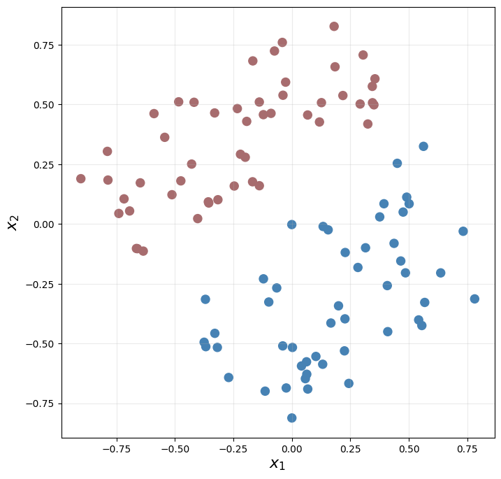

```python
margin = 0.1 # subject to experiment
perc = Perceptron(n=100, margin=margin)
perc.plot_model(decision_boundary=False)
```

- **Functionality:** The `margin` parameter in the Perceptron class influences the minimum distance between the training examples of different classes.
- **Experimentation:** We can modify the margin in the range of 0.01 to 0.4 and observe the changes on the scatter plot:
  - **Small margin:** The classes are very close, potentially making classification harder.
  - **Large margin:** There is a wider gap between the classes, making them easier to separate.

By adjusting the margin, we can see visually how the separation between classes changes, which in turn influences the performance and learning dynamics of your Perceptron classifier.

#### Part 4 B [20 points]

Modify the `train` method in the `Perceptron` class to perform the Perceptron Learning Algorithm and learn weights ${\bf w}$ and bias $b$ that perfectly classify the linearly separable training data. Your implementation should:

- Visit all training examples in a random shuffled order over each training epoch. (**Note:** np.random.shuffle() will be helpful here)
- Terminate when you finish an epoch without making a single classification error or when you hit the maximum number of epochs.
- Use the `self.num_mistakes` counter to count the total number of classification errors over the entire training process. (**Note:** You should also have a seperate counter variable for keeping track of mistakes within each epoch.)

Notes:

You should **not** use Scikit-Learn's Perceptron object in your solution. It's a good idea to implement a stopping criterion based on the `max_epochs` parameter as the first step. Later we'll look at training sets that will terminate on their own, but implementing a stopping mechanism will save you some pain in the development process. Do not change the initial guess for the weights and bias. These values were chosen to match the example done in lecture for the unit tests.

```python
from tests import tests
tests.run_test_suite('prob 1.4B', Perceptron)
```

[output not shown]

#### Part 4 C [15 points]

Modify the `plot_model` method so that it plots the learned decision boundary with the training data. Demonstrate that your method is working by training a perceptron with a margin of your choice and displaying the resulting plot. What is the equation of the learned decision boundary? Use symbols not numbers (i.e., use Latex).

The code checks if `decision_boundary` is True. If so, it generates a range of $x_1$ values and computes the corresponding $x_2$ values using the decision boundary equation

$$ w_1 x_1 + w_2 x_2 + b = 0 \quad \text{or} \quad x_2 = -\frac{w_1 x_1 + b}{w_2}, $$

and plots this line over the training data. If $w_2=0$, it plots a vertical line at $x_1 = -\frac{b}{w_1}$.

```
Weights [-0.73574249  0.89832955]
Bias 0
```

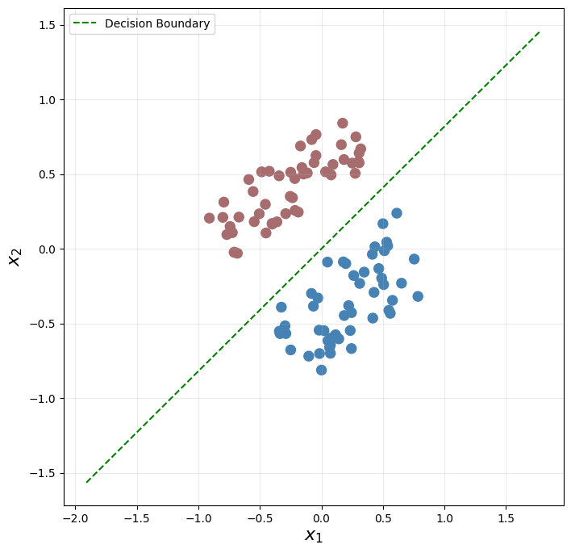

```python
perc = Perceptron(n=100, margin=0.2)
perc.train()
print("Weights",perc.w)
print("Bias",perc.b)
perc.plot_model(decision_boundary=True)
```

### Part 5 [25 points]

An important theorem states that, if you train a perceptron on linearly separable training data with margin $M > 0$ and each training point satisfies $\|{\bf x}\|_2 \leq 1$ then the Perceptron algorithm will complete after making at most $1/M^2$ classification mistakes.

Numerically verify this theorem by doing the following:

- Train multiple Perceptrons with $n = 100$ and different margins ($M=0.3, 0.1, 0.01, 0.001,$ and $0.0001$).
- Produce a log-log plot with $1/M$ on the horizontal axis and the total numbers of mistakes on the vertical axis.
- On the same set of axes, plot the theoretical upper bound on the number of training mistakes.

Hint: The computed number of mistakes should be below the upper bound $1/M^2$ stated in the theorem. If it is not, there is probably something wrong with your code.

Often we run multiple simulations and compute an averaged number of total mistakes for each margin, but it is fine if you only do one simulation for each margin value.

```
Margin: 0.30000, Observed Mistakes: 4, Theoretical Bound: 11.11
Margin: 0.10000, Observed Mistakes: 12, Theoretical Bound: 100.00
Margin: 0.01000, Observed Mistakes: 141, Theoretical Bound: 10000.00
Margin: 0.00100, Observed Mistakes: 199, Theoretical Bound: 1000000.00
Margin: 0.00010, Observed Mistakes: 388, Theoretical Bound: 100000000.00
```

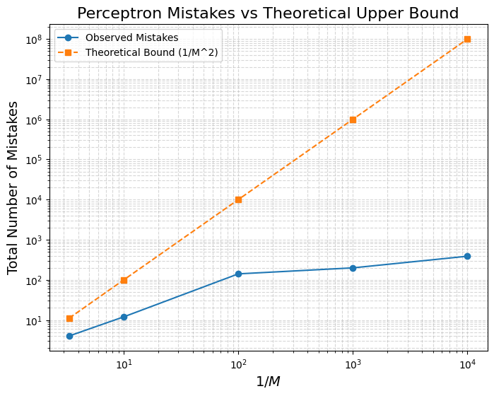

```python
margins = [0.3, 0.1, 0.01, 0.001, 0.0001]

observed_mistakes = []
theoretical_bound = []
inv_M_values = []

for M in margins:
    p = Perceptron(n=100, margin=M)
    p.train(max_epochs=100)

    mistakes = p.num_mistakes
    observed_mistakes.append(mistakes)

    bound = 1.0 / (M ** 2)
    theoretical_bound.append(bound)

    inv_M_values.append(1.0 / M)

    print(f"Margin: {M:.5f}, Observed Mistakes: {mistakes}, Theoretical Bound: {bound:.2f}")

plt.figure(figsize=(8, 6))
plt.loglog(inv_M_values, observed_mistakes, 'o-', label='Observed Mistakes')
plt.loglog(inv_M_values, theoretical_bound, 's--', label='Theoretical Bound (1/M^2)')
plt.xlabel(r'$1/M$', fontsize=14)
plt.ylabel("Total Number of Mistakes", fontsize=14)
plt.title("Perceptron Mistakes vs Theoretical Upper Bound", fontsize=16)
plt.legend()
plt.grid(True, which="both", ls="--", alpha=0.5)
plt.show()
```

### Optional survey.

Please fill out this anonymous [survey](https://docs.google.com/forms/d/e/1FAIpQLSdmCXMKyP5THhaH_FU7-elaxd7Yf0vsyX2Tf5XMbz43kc1Apw/viewform?usp=header) if you wish to share your feedback for how to improve the course.

**Acknowledgment** : Chris Ketelsen